# Examining impact of severe weather events on public health and economy

## Synopsis

In the report below, we determine the impact of severe weather events on population health and economy. The data is obtained from the U.S. National Oceanic and Atmospheric Administration’s (NOAA) storm database. The impact on population health is evaluated by determining the average fatalities and injuries per event type. From the results, it is clear heat related events & hurricanes cause the most damage to population health. To determine the impact on the econnomy, we compute the total monetry loss based on property damage and crop damange. The total monetry loss is then averaged based on each event type. In terms of economic consequences, hurricanes & typhoons are by far the most damaging weather event.

## Data Processing

In order to load the data into R, the bz2 file is first unzipped using the bunzip2 function in the R.utils package. This package is not part of the standard R package and would need to be installed. In order to prvent an error from bunzip2 on subsequent runs, a check is added to see if the csv file already exists.

```r
if (!file.exists("repdata-data-StormData.csv")){
    install.packages("R.utils")
    library(R.utils)
    bunzip2("repdata-data-StormData.csv.bz2")
}
```

The data is loaded into a data frame using the read.csv function.

```r
storm.data <- read.csv("repdata-data-StormData.csv")
```

Several rows in the storm dataset have a summary of a particular event. These observations don’t have any numerical data and are therefore excluded from the analysis.

```r
storm.data <- subset(storm.data,!grepl("summary", storm.data$EVTYPE, ignore.case = TRUE))
```

In order to calculate the total monetry loss, the DMG & DMGEXP fields need to be used. The PROPDMGEXP and CROPEXPDMG fields are expressed in terms of hundreds (h or H), thousands (k or K), millions (m or M) or billions (b or B). All other non numeric values (?,- and +) are replaced by a multiplier of 1.

The final cash loss is calculated by using the following equation:

cash = cropdmg * (10 ^ cropdmpexp) + propdmg * (10 ^ propdmpexp)

```r
pattern <- c("[hH]","[mM]", "[kK]","[bB]", "[-+?]", "^$")
replacement <- c("2","6","3","9","0","0")
for (i in 1:length(pattern)) {
    storm.data$CROPDMGEXP <- sub(pattern[i],replacement[i], storm.data$CROPDMGEXP)
    storm.data$PROPDMGEXP <- sub(pattern[i],replacement[i], storm.data$PROPDMGEXP)
}

storm.data$CROPDMGEXP <- as.numeric(storm.data$CROPDMGEXP)
storm.data$PROPDMGEXP <- as.numeric(storm.data$PROPDMGEXP)

storm.data$TOTALCASH <- (storm.data$CROPDMG * (10^storm.data$CROPDMGEXP)) + (storm.data$PROPDMG * (10^storm.data$PROPDMGEXP))
```

## Exploratory Analysis

In order to study, the impact of different events on population health, the summary function is useful.

```r
summary(storm.data$FATALITIES)
```

```
##    Min. 1st Qu.  Median    Mean 3rd Qu.    Max.
##       0       0       0       0       0     583
```

```r
summary(storm.data$INJURIES)
```

```
##    Min. 1st Qu.  Median    Mean 3rd Qu.    Max.
##     0.0     0.0     0.0     0.2     0.0  1700.0
```

From the summaries, we see that median & 3rd quartile for both Injuries and Fatalities is zero. However, the max value is large for both the variables. Hence, the data distribution is long tailed.

To calculate the total impact on human population and economy, we need to sum up the fatalities, injuries & total cash loss for all event types across the dataset. The dataset is melted with reshape2 package to retain only required variables. It is then re-cast to compute the sum for each variable.

```r
require(reshape2)
storm.human.melt <- melt(storm.data, id.vars=c("EVTYPE"), measure.vars=c("FATALITIES", "INJURIES", "TOTALCASH"))
storm.dcast.sum <- dcast(storm.human.melt, EVTYPE~variable,sum)
```

The events which have caused the most harm to population health are:

```r
head(storm.dcast.sum[order(storm.dcast.sum$FATALITIES,decreasing=TRUE),c(1,2)],5)
```

```
##             EVTYPE FATALITIES
## 767        TORNADO       5633
## 129 EXCESSIVE HEAT       1903
## 152    FLASH FLOOD        978
## 274           HEAT        937
## 463      LIGHTNING        816
```

```r
head(storm.dcast.sum[order(storm.dcast.sum$INJURIES,decreasing=TRUE),c(1,3)],5)
```

```
##             EVTYPE INJURIES
## 767        TORNADO    91346
## 789      TSTM WIND     6957
## 169          FLOOD     6789
## 129 EXCESSIVE HEAT     6525
## 463      LIGHTNING     5230
```

Clearly, TORNADOS have caused the most damage to population health (in terms of total injuries and fatalities) in the last 60 years.

In terms of economic consequences, the most damaging weather events are:

```r
head(storm.dcast.sum[order(storm.dcast.sum$TOTALCASH,decreasing=TRUE),c(1,4)],5)
```

```
##                EVTYPE TOTALCASH
## 169             FLOOD 1.503e+11
## 410 HURRICANE/TYPHOON 7.191e+10
## 767           TORNADO 5.736e+10
## 669       STORM SURGE 4.332e+10
## 243              HAIL 1.876e+10
```

However, it may be more interesting to see the average impact of each EVENT type. We will explore this relationship in the next section.

## Results

To explore the average impact of each event, a new dataset with the frequency of each event is created. This is merged with the existing casted dataset to generate a new dataset.

```r
EVTYPE.table <- as.data.frame(table(storm.data$EVTYPE))
names(EVTYPE.table) <- c("EVTYPE", "Freq")
storm.final <- merge(storm.dcast.sum, EVTYPE.table)
tornados <- storm.final[storm.final$EVTYPE=="TORNADO",]
```

From the above dataset, there have been 60652 tornadoes in the United States over the last 60 years. This explains the larger number of injuries seen due to tornadoes.

Now, we investigate the average impact per event type. To do this, we can divide the total fatalities, injuries & total cash loss by the total events recorded. In the analysis, we have excluded any events that have seen fewer than 20 occurances in the dataset.

```r
storm.final$FATALITIES.per.event <- storm.final$FATALITIES/storm.final$Freq
storm.final$INJURIES.per.event <- storm.final$INJURIES/storm.final$Freq
storm.final$TOTALCASH.per.event <- storm.final$TOTALCASH/storm.final$Freq
storm.final.sub <- subset(storm.final, storm.final$Freq > 20)
```

The following plots represent the average impact per event type on fatalities, injuries & total cash loss. We only plot the top 5 events to keep the plots readable.

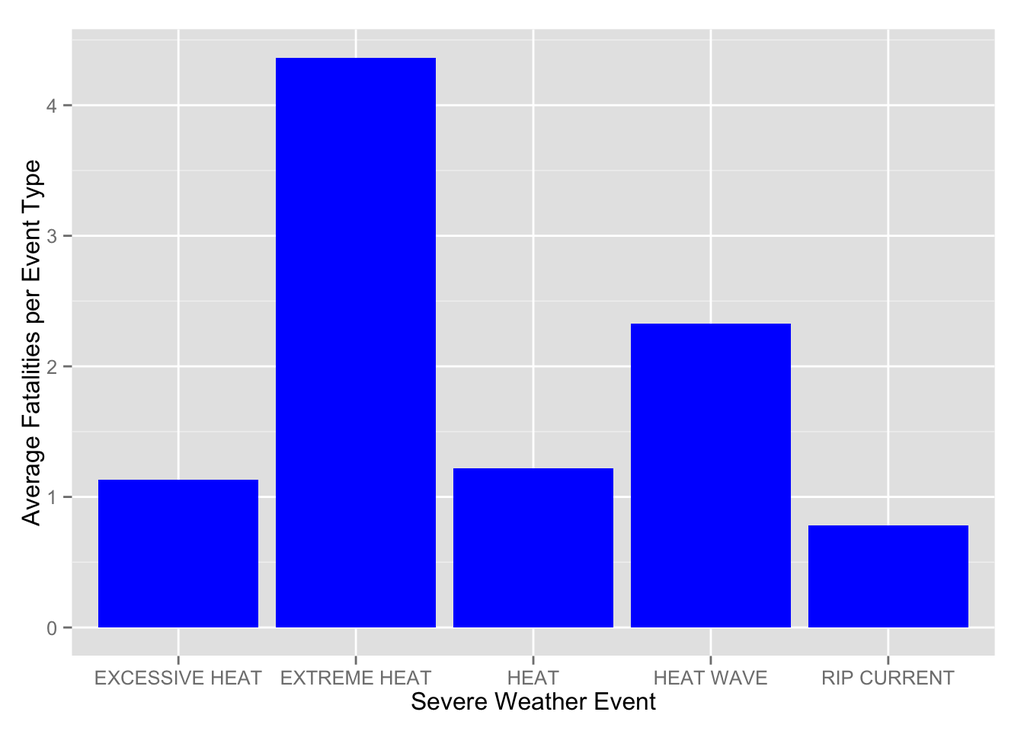

Figure 1: Average Impact of severe weather events on fatalities

```r
require(ggplot2)
ggplot(head(storm.final.sub[order(storm.final.sub$FATALITIES.per.event,decreasing=TRUE),],5), aes(x=EVTYPE, y=FATALITIES.per.event)) + geom_bar(stat="identity", fill = "blue") + xlab("Severe Weather Event") + ylab("Average Fatalities per Event Type")
```

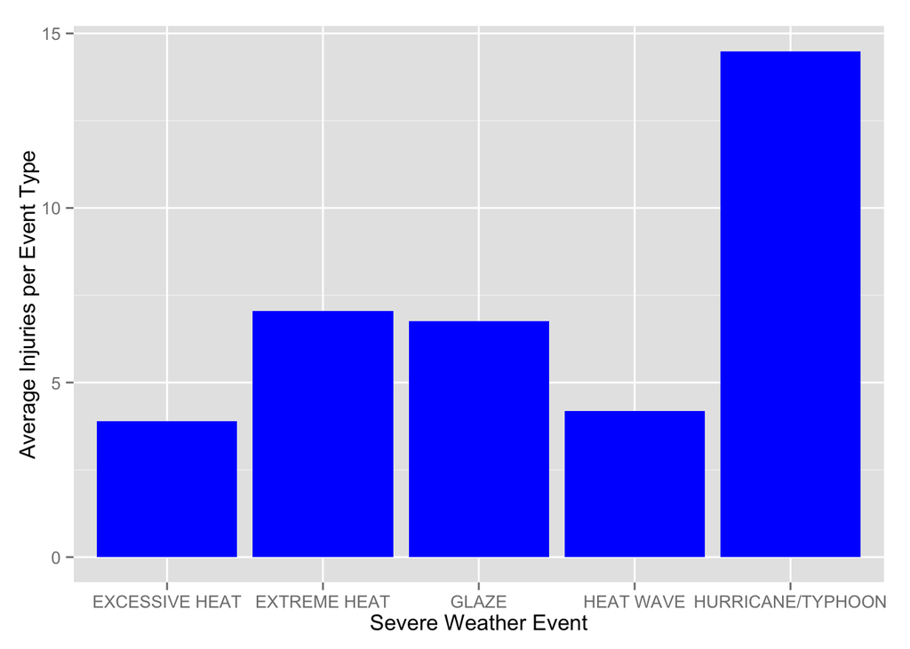

Figure 2: Average Impact of severe weather events on injuries

```r
ggplot(head(storm.final.sub[order(storm.final.sub$INJURIES.per.event,decreasing=TRUE),],5), aes(x=EVTYPE, y=INJURIES.per.event)) + geom_bar(stat="identity", fill = "blue") + xlab("Severe Weather Event") + ylab("Average Injuries per Event Type")
```

From the above figures, we can see that the **Heat related events (Heat Wave, Extereme Heat, Excessive Heat)** are most damaging in terms of fatalities. **Hurricanes and Heat related events** cause the most injuries per event.

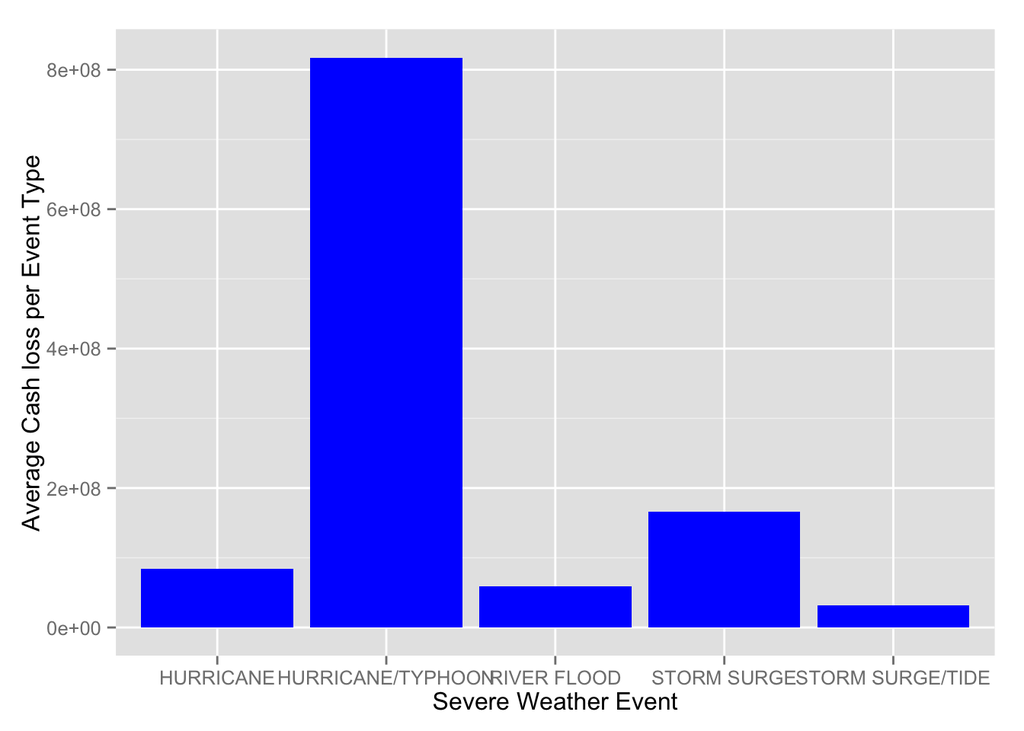

Figure 3: Average Impact of severe weather events on economy

```r
ggplot(head(storm.final.sub[order(storm.final.sub$TOTALCASH.per.event,decreasing=TRUE),],5), aes(x=EVTYPE, y=TOTALCASH.per.event)) + geom_bar(stat="identity", fill = "blue") + xlab("Severe Weather Event") + ylab("Average Cash loss per Event Type")
```

**Hurricanes/Typhoons** have the greatest consequences on the economy. On average, each hurricane has caused a total monetry loss of $800M.